# TD_ACP_REV

ISLA Thomas

09/12/2020

# TD ACP

## Exploration des données :

```r
getwd()
```

```
## [1] "C:/Users/thoma/OneDrive/Bureau/Cours/A4/Machine Learning/TD6_ACP"
```

```r
dataset=read.table(file="iris.data",header = TRUE,sep=',')
head(dataset,5)
```

```
##   sepal_length sepal_width petal_length petal_width  class
## 1          5.1         3.5          1.4         0.2 setosa
## 2          4.9         3.0          1.4         0.2 setosa
## 3          4.7         3.2          1.3         0.2 setosa
## 4          4.6         3.1          1.5         0.2 setosa
## 5          5.0         3.6          1.4         0.2 setosa
```

Régardons visuellement nos données :

```r
library(caret)
```

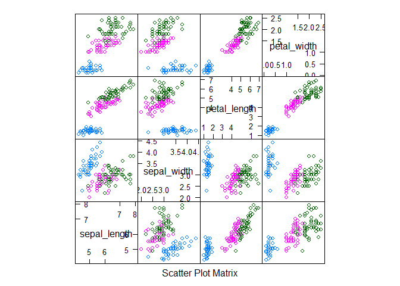

```r
featurePlot(dataset[,1:4],dataset[,5],plot='pairs')
```

On observe nos variables quantitatives deux par deux. On observe bien nos 3 classes. Dans l’ensemble les clusters ont une forme ellipsoïdale.

Une librairie est plus indiquée pour cette analyse.

```r
library(GGally)
```

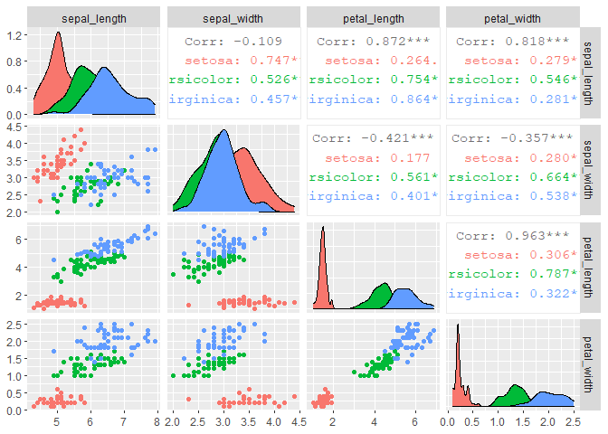

```r
ggpairs(dataset, columns = 1:4, ggplot2::aes(colour=class))
```

Ou encore.

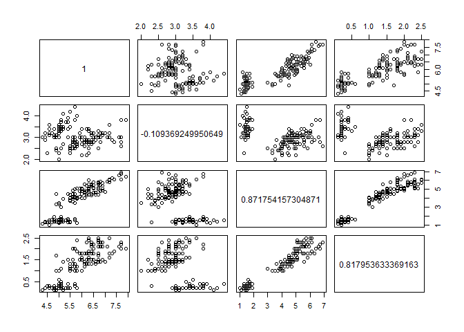

```r
library("corrplot")
plot(dataset[,1:4],cor(dataset[,1:4]))
```

On peut aussi les visualiser en 3D avec la librairie suivante, si l’on est en 3 dimensions UNIQUEMENT. Exemple dans le TD ACP.

```r
library(rgl)
```

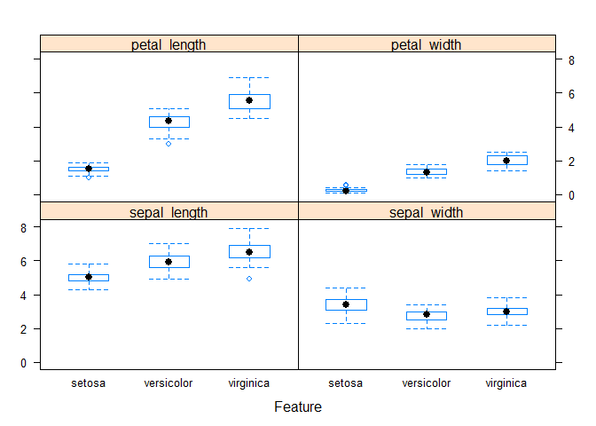

```r
featurePlot(dataset[,1:4],dataset[,5],plot='box')
```

La relation entre notre variable réponse et nos variables prédicteurs est assez visible. On pourrait toutefois faire un test ANOVA pour affirmer statistiquement cette relation.

On remarque également plusieurs outliers, observons les plus en détails.

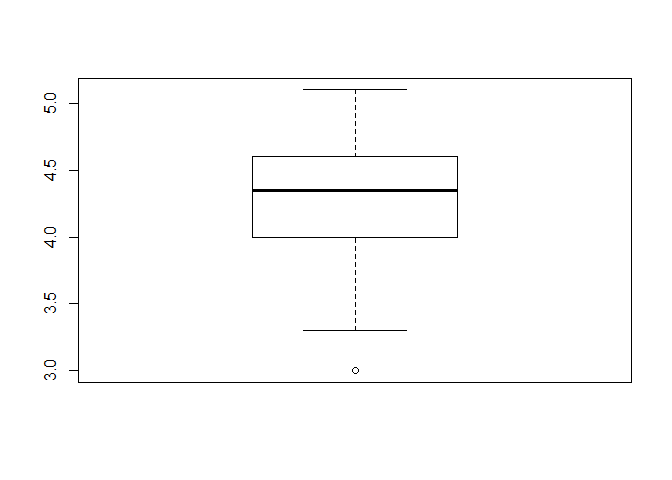

```r
boxplot(dataset[dataset$class=='versicolor',3])
```

```r
outliers=boxplot.stats(dataset[dataset$class=='versicolor',3])$out
outliers
```

```
## [1] 3
```

La valeur de l’outliers est 3, observons l’individus correspondant.

```r
outliersIndex=which(dataset[,3] %in% c(outliers))
outliersIndex
```

```
## [1] 99
```

```r
dataset[outliersIndex,]
```

```
##    sepal_length sepal_width petal_length petal_width      class
## 99          5.1         2.5            3         1.1 versicolor
```

On doit alors décider si l’on décide de garder ou non l’individu. Ici nous le conserverons.

Regardons de plus le boxPlot de l’épaisseur de la pétale pour la classe setosa qui semble très écrasé.

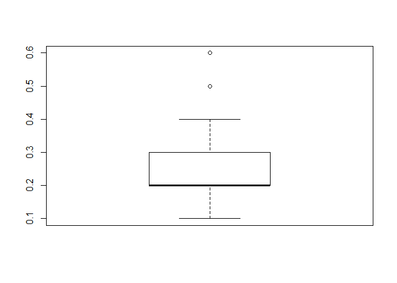

```r
boxplot(dataset[dataset$class=='setosa',4])
```

On a deux outliers très importants.

```r
outliers2=boxplot.stats(dataset[dataset$class=='setosa',4])$out

outliersIndex2=which(dataset[,4] %in% c(outliers2))

dataset[outliersIndex2,]
```

```
##    sepal_length sepal_width petal_length petal_width  class
## 24          5.1         3.3          1.7         0.5 setosa
## 44          5.0         3.5          1.6         0.6 setosa
```

Pour visualiser refaisons le box Plot initial sans ces individus. On les conservera par la suite.

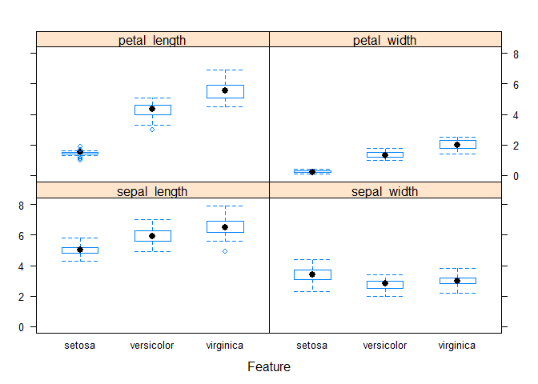

```r
featurePlot(dataset[-outliersIndex2,1:4],dataset[-outliersIndex2,5],plot='box')
```

Mauvaise idée.

Enfin on n’oublie pas de regarder le nombre d’individu dans chaque classes.

```r
table(dataset$class)
```

```
##
##     setosa versicolor  virginica
##         50         50         50
```

On a trois classe égale en terme de nombre d’individu.

## ACP

Avant propos, en 3D une forme d’ellipse plate indique que l’on peut supprimer un axe (une dimension). En effet cette forme est réalisable dans un plan 2D donc une dimension en trop.

On utilise deux packages pour voir le mieux.

```r
library(FactoMineR)
```

```r
ACP=princomp(dataset[,1:4],cor=T)

ACP_Facto=PCA(dataset,scale.unit = TRUE,quali.sup = 5,graph = FALSE)
```

Avec “princomp” :

```r
summary(ACP)
```

```
## Importance of components:
##                           Comp.1    Comp.2     Comp.3      Comp.4
## Standard deviation     1.7061120 0.9598025 0.38386622 0.143553848
## Proportion of Variance 0.7277045 0.2303052 0.03683832 0.005151927
## Cumulative Proportion  0.7277045 0.9580098 0.99484807 1.000000000
```

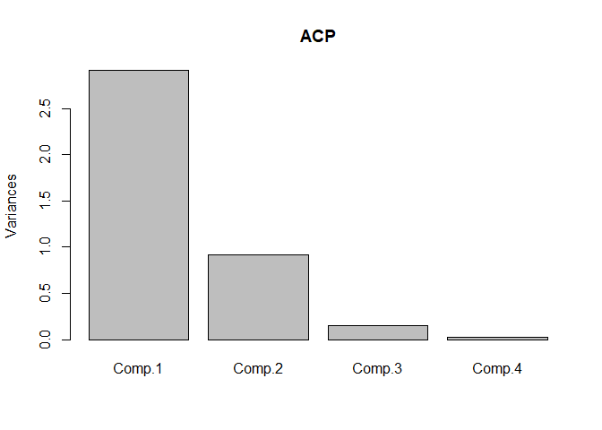

```r
plot(ACP)
```

Avec la fonction de la librairie Facto

```r
summary(ACP_Facto)
```

```
##
## Call:
## PCA(X = dataset, scale.unit = TRUE, quali.sup = 5, graph = FALSE)
##
##
## Eigenvalues
##                        Dim.1   Dim.2   Dim.3   Dim.4
## Variance               2.911   0.921   0.147   0.021
## % of var.             72.770  23.031   3.684   0.515
## Cumulative % of var.  72.770  95.801  99.485 100.000
##
## Individuals (the 10 first)
##                  Dist    Dim.1    ctr   cos2    Dim.2    ctr   cos2    Dim.3
## 1            |  2.324 | -2.265  1.175  0.950 |  0.506  0.185  0.047 | -0.122
## 2            |  2.201 | -2.086  0.997  0.898 | -0.655  0.311  0.089 | -0.227
## 3            |  2.390 | -2.368  1.284  0.982 | -0.318  0.073  0.018 |  0.051
## 4            |  2.378 | -2.304  1.216  0.939 | -0.575  0.240  0.059 |  0.099
## 5            |  2.483 | -2.389  1.307  0.926 |  0.675  0.329  0.074 |  0.021
## 6            |  2.568 | -2.071  0.982  0.650 |  1.519  1.669  0.350 |  0.031
## 7            |  2.471 | -2.446  1.370  0.980 |  0.075  0.004  0.001 |  0.342
## 8            |  2.249 | -2.234  1.143  0.986 |  0.248  0.044  0.012 | -0.083
## 9            |  2.590 | -2.342  1.256  0.818 | -1.095  0.868  0.179 |  0.154
## 10           |  2.248 | -2.189  1.097  0.948 | -0.449  0.146  0.040 | -0.247
##                 ctr   cos2
## 1             0.067  0.003 |
## 2             0.234  0.011 |
## 3             0.012  0.000 |
## 4             0.044  0.002 |
## 5             0.002  0.000 |
## 6             0.004  0.000 |
## 7             0.530  0.019 |
## 8             0.031  0.001 |
## 9             0.107  0.004 |
## 10            0.275  0.012 |
##
## Variables
##                 Dim.1    ctr   cos2    Dim.2    ctr   cos2    Dim.3    ctr
## sepal_length |  0.891 27.287  0.794 |  0.357 13.862  0.128 | -0.277 51.987
## sepal_width  | -0.449  6.936  0.202 |  0.888 85.665  0.789 |  0.093  5.858
## petal_length |  0.992 33.786  0.983 |  0.020  0.044  0.000 |  0.054  1.985
## petal_width  |  0.965 31.992  0.931 |  0.063  0.428  0.004 |  0.243 40.170
##                cos2
## sepal_length  0.077 |
## sepal_width   0.009 |
## petal_length  0.003 |
## petal_width   0.059 |
##
## Supplementary categories
##                   Dist     Dim.1    cos2  v.test     Dim.2    cos2  v.test
## setosa       |   2.240 |  -2.220   0.983 -11.232 |   0.292   0.017   2.628 |
## versicolor   |   0.744 |   0.492   0.437   2.490 |  -0.549   0.545  -4.941 |
## virginica    |   1.753 |   1.728   0.972   8.742 |   0.257   0.022   2.314 |
##                Dim.3    cos2  v.test
## setosa        -0.044   0.000  -0.988 |
## versicolor    -0.094   0.016  -2.108 |
## virginica      0.138   0.006   3.096 |
```

Cette fonction est bien mieux. On remarque également que les trois premiers axes résument 99.5% de la variabilité totale. Le dernier axe contient très peu d’informations, on peut le supprimer.

Pour le premier axe, les variables “petal_length” et “petal_width” contribue le plus à sa formation. On endéduit que cette axe représente les pétales. Le deuxième axe représente les sépales.

```r
ACP_Facto$call$col.w
```

```
## [1] 1 1 1 1
```

Chaque variable a le même poids.

Maintenant que nous sommes en 3 dimensions nous sommes capable d’afficher nos données. Jetons un oeil.

```r
plot3d(ACP_Facto$ind$coord,col=as.numeric(dataset$class))
```

[output not shown]

Poursuivons l’analyse de l’ACP :

On réalise le screen plot qui permet de déterminer le nombre de PC staisfaisante.

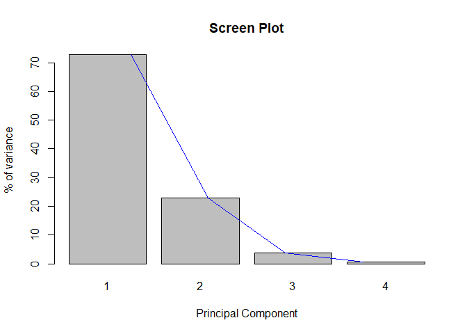

```r
eigen=ACP_Facto$eig
barplot(eigen[,2],names.arg=1:nrow(eigen),main="Screen Plot",xlab="Principal Component"
        ,ylab="% of variance")
lines(c(1,2,3,4),eigen[,2],col='blue')
```

Pas très utile on redit simplement ce qu’on a dit précédemment. Normalement on utilise la technique du coude pour déterminer le nombre optimal de dimension.

```r
library(factoextra)
```

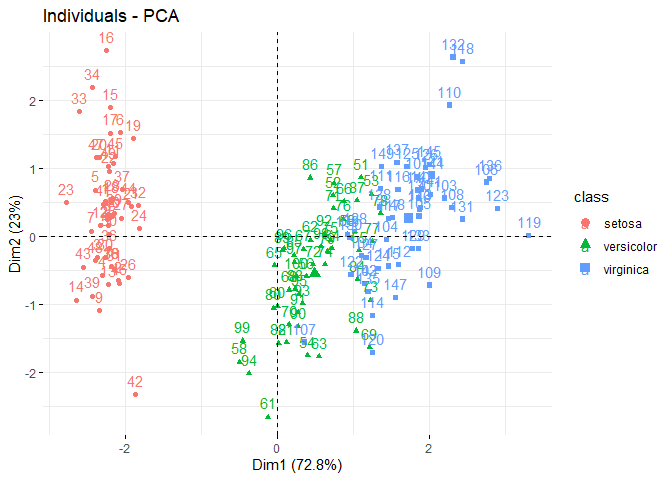

```r
fviz_pca_ind(ACP_Facto,habillage = "class")
```

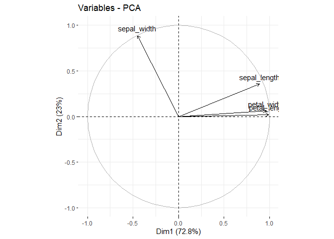

```r
fviz_pca_var(ACP_Facto)
```

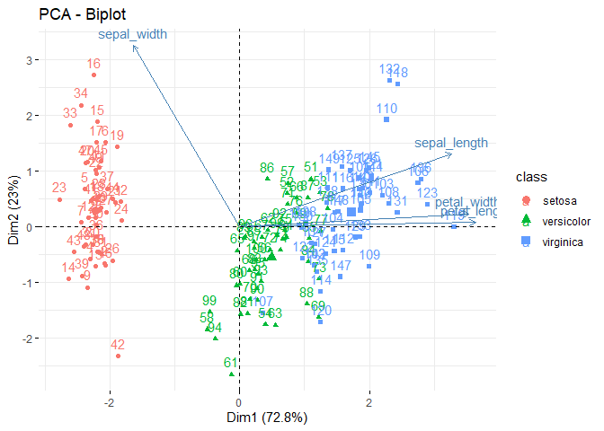

```r
fviz_pca_biplot(ACP_Facto,habillage="class")
```